# Análise dos dados da Apple Store e Play Store

## Gabriel Dias de Abreu

## Sistemas Apoio à decisão - UFJF 2019.1

### 23/04/2019

# Objetivo do Estudo:

# Gerar conhecimento para o contexto de um desenvolvedor mobile adentrando o mercado.

## Dessa forma,

### Analizando as seguintes features das duas prinicipais lojas de aplicativos mobile

- Categoria - classificação do aplicativo por parte da loja, classes mostradas adiante nos histogramas (discreto e qualitativo).
- Rating - classificação do aplicativo na loja, atributo discreto no conjunto [0, 1, 2, 3, 4, 5],
- Size - tamanho em Bytes do aplicativo, foi utilizado para indicar o quanto um aplicativo foi bem trabalhado, [o, inf] contínuo
- Price - preço em dólares para aplicativos comprados pela loja, contínuo [0, 400],
- Reviews - quantidade de usuários que avaliaram o aplicativo, contínuo [0, inf],
- Content Rating - faixa etária para o aplicativo, discreto, apresentado no histograma

# Features Retiradas da base de dados da Apple Store

### {'ver', 'ipadSc_urls.num', 'currency', 'Unnamed: 0', 'lang.num', 'rating_count_ver', 'sup_devices.num', 'id', 'user_rating_ver', 'vpp_lic'}

# Features Retiradas da base de dados da Play Store

### {'Type', 'Genres', 'Current Ver', 'Android Ver', 'Installs', 'Last Updated'}

```python
%%html
<style>
div.input {
    display:none;
}
</style>
```

## Quantidade de Apps em cada loja e intersecção

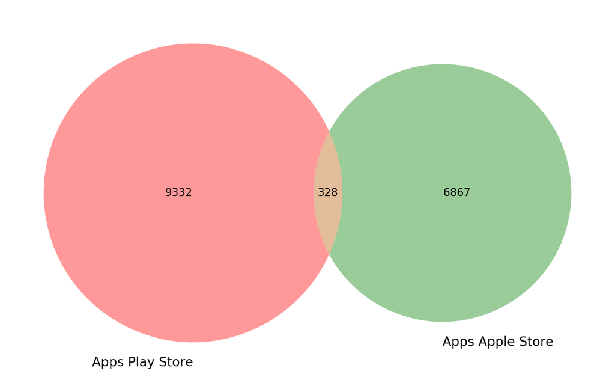

```python
plotaVenn()
# print('quantidade de APPs e intersecção')
```

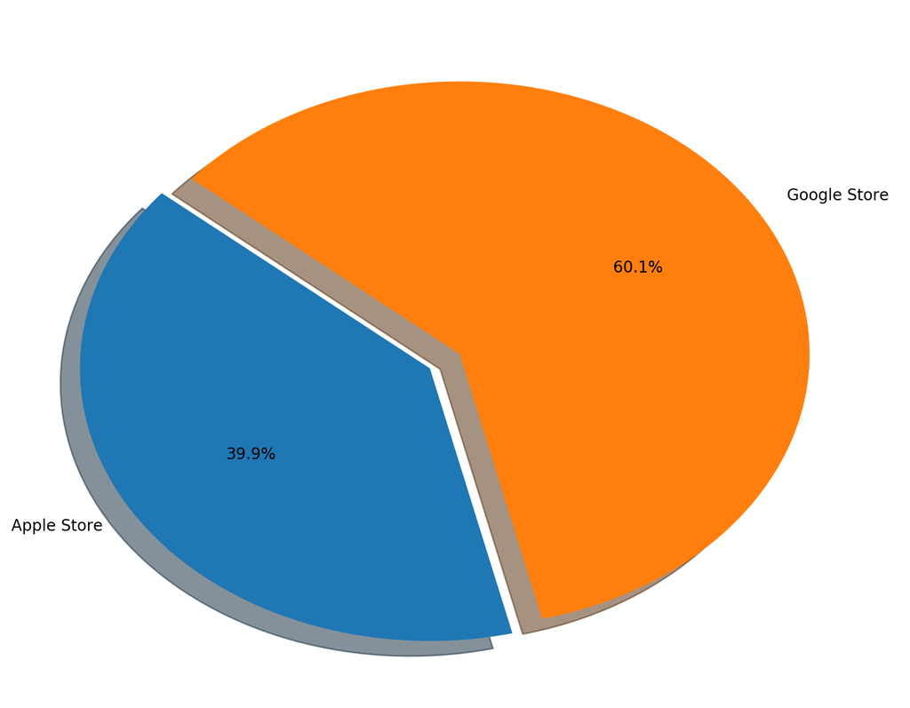

```python
plotaQtdApps()
```

# Categorias Dos Aplicativos

## Categorias dos aplicativos e sua quantidade

# Qual categoria de aplicativo faz mais sucesso no universo mobile para um desenvolvedor mobile tomar como foco e publicar?

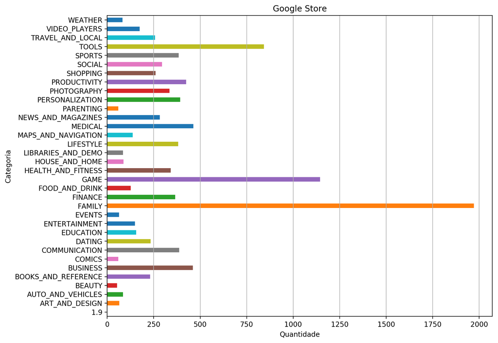

```python
plotaQtdAppsCategoriasGoog()
```

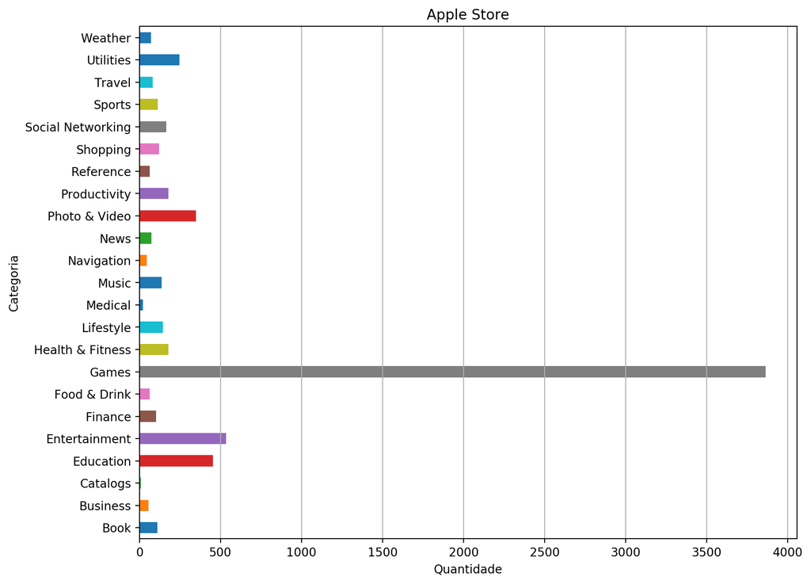

```python
plotaQtdAppsCategoriasAppl()
```

# As duas lojas tem como grande parte das publicações Jogos sendo portanto uma categoria promissora

## uma segunda categoria seriam aplicativos educativos e de família

# Observações

- Os jogos parecem ser uma tendência nos celulares
- Removido o registro com problemas no rate e na categoria
- App de Família: "Designed for Families expands the visibility of your family content on Google Play, helping parents easily find your family-friendly apps and games throughout the store. Other features create a trusted environment that empowers parents to make informed decisions and engage with your content." https://developer.android.com/google-play/guides/families

# Tamanho Aplicativos

## Problema:

## Os dados da Play store estao em 2.2MB enquanto a apple em 2200000B

## 17% dos dados de tamanho do aplicativo da play store estão como "variaveis com dispositivo"

- imputando os dados que tem "Variavel com dispositivo" como a mediana da categoria;
- transformando os dados da Play Store em bytes

# Observando a qualidade ou reserva de mercado pelo tamanho dos aplicativos. Qual seria a melhor loja para começar a publicar e testar um MVP?

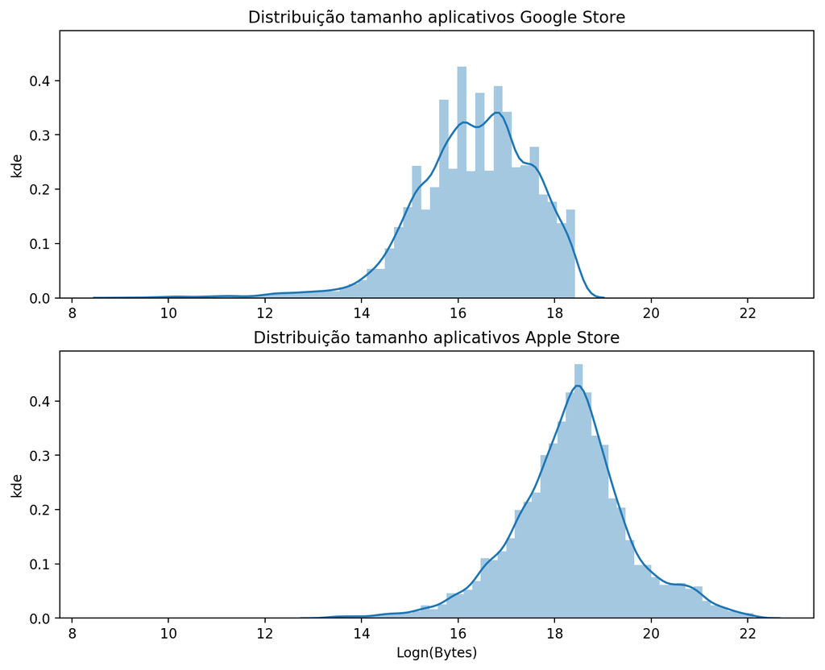

```python
plotaDistribuicaoTamanhos()
```

# Fica evidente pelas Distribuições em *LOGN* que a PlayStore possui melhores oportunidades para projetos iniciais em validação

# Preços cobrados por aplicativos em cada plataforma

# Como monetizar o meu aplicativo em cada loja?

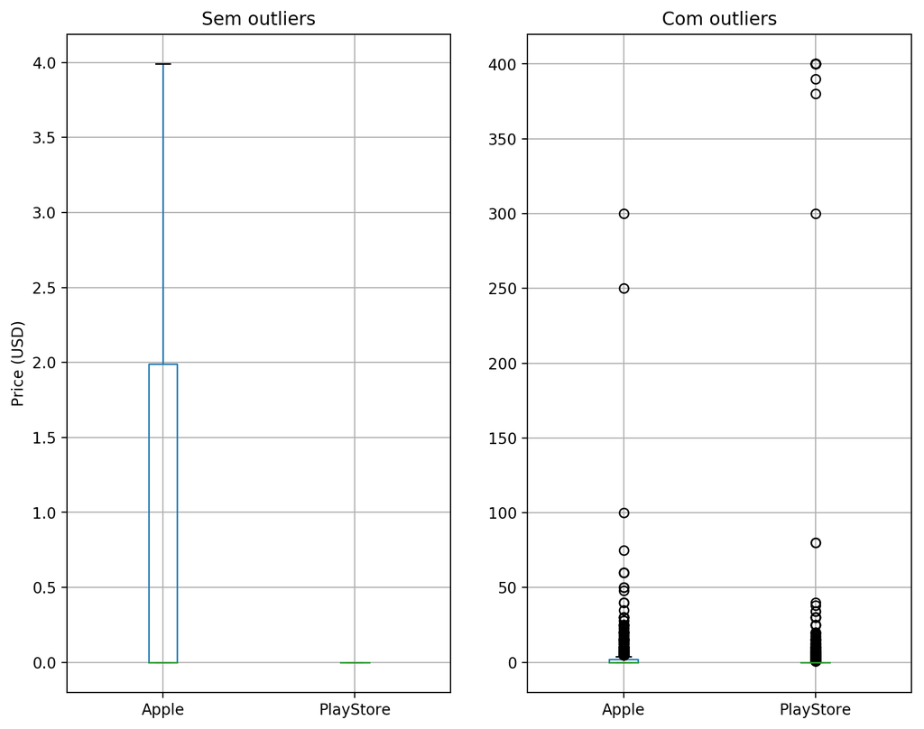

```python
plotaPrecoApps()
```

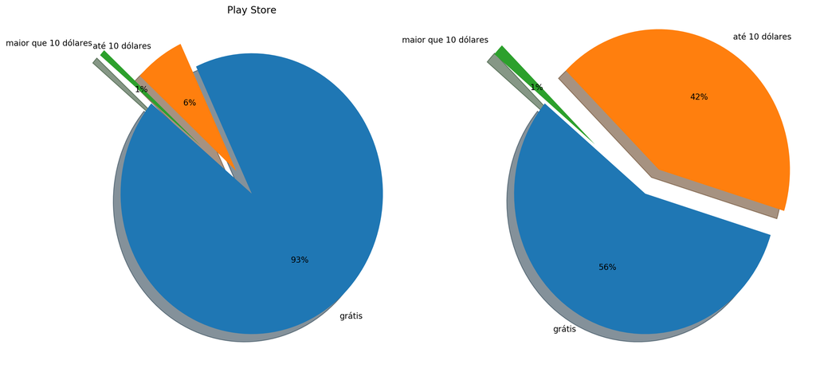

```python
plotPrecoAppsPie()
```

# Ambas as lojas parecem adotar um modelo gratuito com propagandas. No entanto, na Apple Store é viável a venda por até 10 dólares sendo comum essa prática e enraizada na cultura dos usuários.

# Faixa etária

- Manipulação para ficarem na mesma codificação
- Um registro tinha a categoria errada, foi corrigido olhando o site

# Qual público devo privilegiar para cada loja?

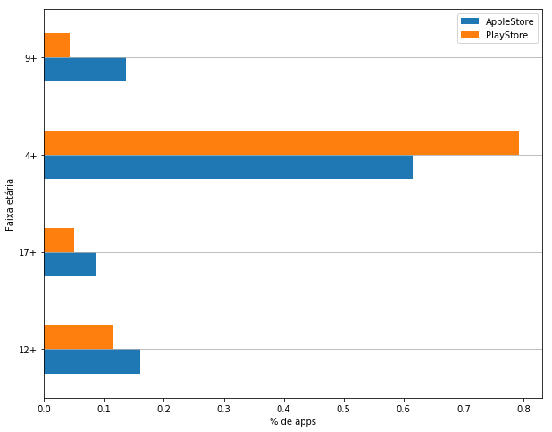

```python
plotaFaixaEtaria()
```

# A maioria dos aplicativos são livres para todos os públicos (4+), portanto, aplicativos de propósito geral e livres de faxa etária são os mais viáveis nas duas lojas.

## No entanto, aplicativos para maiores de 17 e 9 anos são mais comuns na Apple Store, assim, como os para maiores de 12 anos, porém, de forma mais discreta.

# Avaliação pelos usuários

- foi discretizada para [0, 1, 2, 3, 4, 5]

# Qual a loja em que terei mais chance de ser bem avaliado?

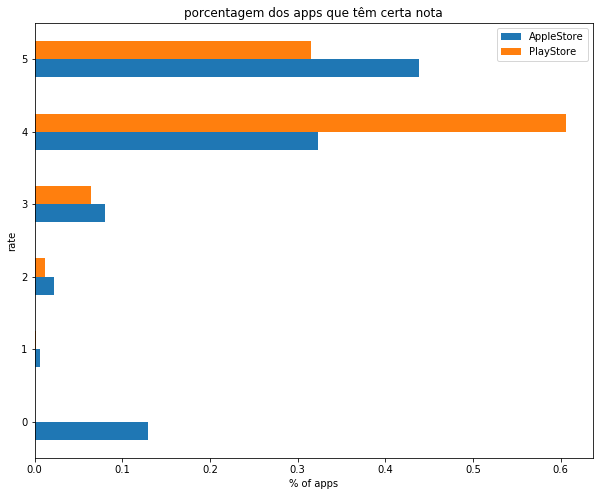

```python
plotaRate()
```

# Os usuários da Apple Store avaliam mais como 5 mostrando um maior engajamento, talvez devido ao modelo de comprar os apps por valores baixos, entretanto, avaliam mais vezes com 0, e 1 podendo ser um risco para os desenvolvedores.

# Os usuários da Play Store tendem a dar nota 4 e 5 na maior parte das vezes, o que configura um cenário mais estável para um produto que queira evitar extremos como nota 0

# Número de pessoas que avaliam por Nota

# Qual o tamanho do engajamento para avaliar meu aplicativo em cada loja?

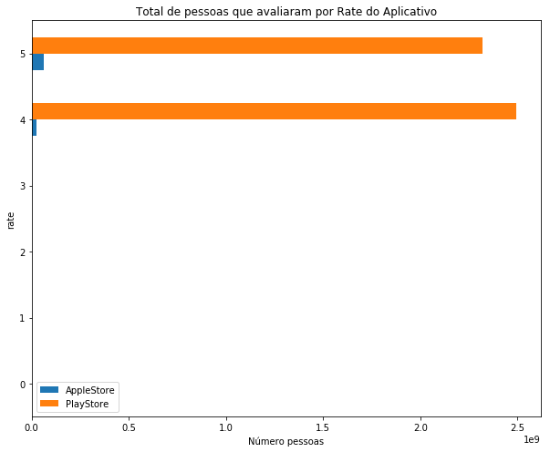

```python
plotaAvaliacoes()
```

# Os usuários da Play Store são mais engajados em avaliar com notas altas quando identificam a necessidade.

# Matriz de correlação entre Atributos

# Existe alguma correlação entre preço e avaliação do aplicativo?

# ou entre tamanho e avaliação?

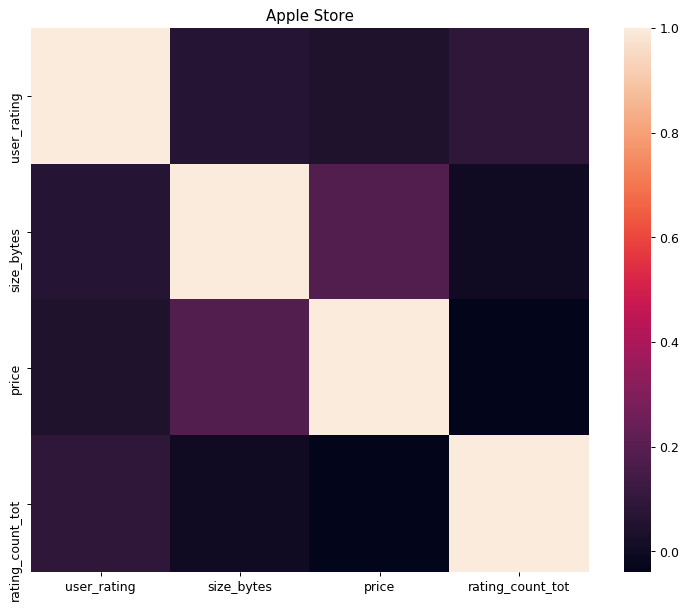

```python
plt.figure(figsize=[10, 8], dpi=90)
sns.heatmap(dadosAppleStore.corr())
plt.title('Apple Store')
plt.show()
```

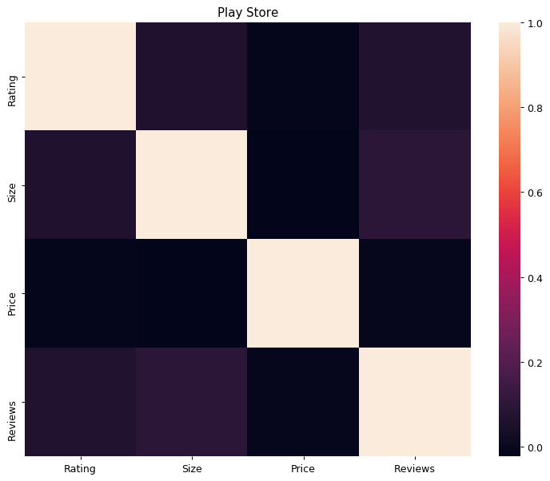

```python
plt.figure(figsize=[10, 8], dpi=90)
sns.heatmap(dadosPlayStore.corr())
plt.title('Play Store')
plt.show()
```

# Nenhuma das lojas apresentou uma correlação expressiva, portanto, não parecem ser fatores correlacionados

# Clusterização da Base de Dados

# Quais grupos avaliam melhor o aplicativo em cada loja para definir meu público-alvo ?

## Tratamento dos dados para aplicar kmeans

```python
print('Antes')
dadosPlayStore.head()
```

```
Antes
```

|  | App | Category | Rating | Size | Price | Reviews | Content Rating |
| --- | --- | --- | --- | --- | --- | --- | --- |
| 0 | Photo Editor & Candy Camera & Grid & ScrapBook | ART_AND_DESIGN | 4 | 19000000.0 | 0.0 | 159 | 4+ |
| 1 | Coloring book moana | ART_AND_DESIGN | 4 | 14000000.0 | 0.0 | 967 | 4+ |
| 2 | U Launcher Lite – FREE Live Cool Themes, Hide ... | ART_AND_DESIGN | 5 | 8700000.0 | 0.0 | 87510 | 4+ |
| 3 | Sketch - Draw & Paint | ART_AND_DESIGN | 5 | 25000000.0 | 0.0 | 215644 | 12+ |
| 4 | Pixel Draw - Number Art Coloring Book | ART_AND_DESIGN | 4 | 2800000.0 | 0.0 | 967 | 4+ |

```python
dadosPlayStore['Content Rating'] = list(map(filtraEtaria, dadosPlayStore['Content Rating']))
```

```python
dadosPlayStoreCluster = pd.get_dummies(dadosPlayStore['Category'])
dadosPlayStoreCluster['Rating'] = dadosPlayStore['Rating']
dadosPlayStoreCluster['Size'] = dadosPlayStore['Size']
dadosPlayStoreCluster['Price'] = dadosPlayStore['Price']
dadosPlayStoreCluster['Reviews'] = dadosPlayStore['Reviews']
dadosPlayStoreCluster['Content Rating'] = LabelEncoder().fit_transform(dadosPlayStore['Content Rating'] )

dadosPlayStoreCluster[dadosPlayStoreCluster.columns] = MinMaxScaler().fit_transform(dadosPlayStoreCluster[dadosPlayStoreCluster.columns])
print('Depois')
dadosPlayStoreCluster.head()
```

```
Depois
```

|  | ART_AND_DESIGN | AUTO_AND_VEHICLES | BEAUTY | BOOKS_AND_REFERENCE | BUSINESS | COMICS | COMMUNICATION | DATING | EDUCATION | ENTERTAINMENT | ... | SPORTS | TOOLS | TRAVEL_AND_LOCAL | VIDEO_PLAYERS | WEATHER | Rating | Size | Price | Reviews | Content Rating |
| --- | --- | --- | --- | --- | --- | --- | --- | --- | --- | --- | --- | --- | --- | --- | --- | --- | --- | --- | --- | --- | --- |
| 0 | 1.0 | 0.0 | 0.0 | 0.0 | 0.0 | 0.0 | 0.0 | 0.0 | 0.0 | 0.0 | ... | 0.0 | 0.0 | 0.0 | 0.0 | 0.0 | 0.75 | 0.189931 | 0.0 | 0.000002 | 0.000000 |
| 1 | 1.0 | 0.0 | 0.0 | 0.0 | 0.0 | 0.0 | 0.0 | 0.0 | 0.0 | 0.0 | ... | 0.0 | 0.0 | 0.0 | 0.0 | 0.0 | 0.75 | 0.139927 | 0.0 | 0.000012 | 0.000000 |
| 2 | 1.0 | 0.0 | 0.0 | 0.0 | 0.0 | 0.0 | 0.0 | 0.0 | 0.0 | 0.0 | ... | 0.0 | 0.0 | 0.0 | 0.0 | 0.0 | 1.00 | 0.086922 | 0.0 | 0.001120 | 0.000000 |
| 3 | 1.0 | 0.0 | 0.0 | 0.0 | 0.0 | 0.0 | 0.0 | 0.0 | 0.0 | 0.0 | ... | 0.0 | 0.0 | 0.0 | 0.0 | 0.0 | 1.00 | 0.249936 | 0.0 | 0.002759 | 0.666667 |
| 4 | 1.0 | 0.0 | 0.0 | 0.0 | 0.0 | 0.0 | 0.0 | 0.0 | 0.0 | 0.0 | ... | 0.0 | 0.0 | 0.0 | 0.0 | 0.0 | 0.75 | 0.027917 | 0.0 | 0.000012 | 0.000000 |

5 rows × 38 columns

# Play Store Pair Plot

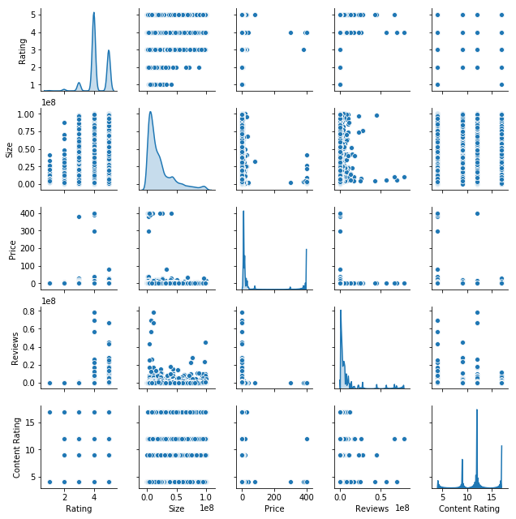

```python
pairPlotPlay()
```

# Apple Store Pair Plot

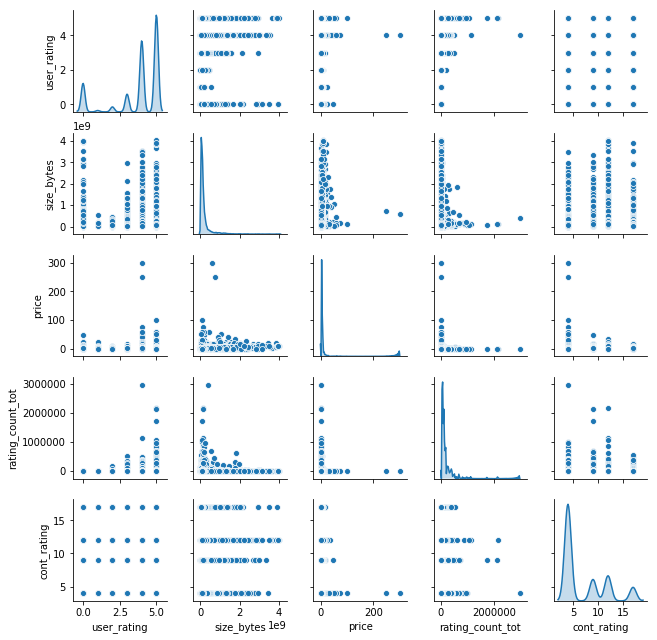

```python
pairPlotApple()
```